# Homework (Chapter 9)

Hwang Seong-Yun

2020 12 2

## packages

```r
library(survival)
library(KMsurv)
library(tidyverse)
library(survminer)
```

## 연습문제 9-1) R 시스템에 내장된 폐암 관련 데이터셋 cancer를 이용하여 다음을 구하시오. cancer는 미국 Mayo Clinic에서 폐암환자를 대상으로 조사한 데이터이다. 포함된 변수는 다음과 같다.

### inst : Institution code

### time : Survival time in days

### status : Censoring status 1=censored, 2=dead

### age : Age in years (Z1)

### sex : Male=1, Female=2 (Z2)

### ph.ecog : ECOG performance score (0=good ~ 5=dead) (Z3)

### ph.karno : Karnofsky performance score (bad=0 ~ good=100) rated by physician (Z4)

### pat.karno : Karnofsky performance score rated by patient (Z5)

### meal.cal : Calories consumed at meals (Z6)

### wt.loss : Weight loss in last six months (Z7)

```r
library(survival)
data(cancer)
head(cancer)
```

```
##   inst time status age sex ph.ecog ph.karno pat.karno meal.cal wt.loss
## 1    3  306      2  74   1       1       90       100     1175      NA
## 2    3  455      2  68   1       0       90        90     1225      15
## 3    3 1010      1  56   1       0       90        90       NA      15
## 4    5  210      2  57   1       1       90        60     1150      11
## 5    1  883      2  60   1       0      100        90       NA       0
## 6   12 1022      1  74   1       1       50        80      513       0
```

```r
cancer$sex <- as.factor(cancer$sex)
summary(cancer)
```

```
##       inst            time            status           age        sex
##  Min.   : 1.00   Min.   :   5.0   Min.   :1.000   Min.   :39.00   1:138
##  1st Qu.: 3.00   1st Qu.: 166.8   1st Qu.:1.000   1st Qu.:56.00   2: 90
##  Median :11.00   Median : 255.5   Median :2.000   Median :63.00
##  Mean   :11.09   Mean   : 305.2   Mean   :1.724   Mean   :62.45
##  3rd Qu.:16.00   3rd Qu.: 396.5   3rd Qu.:2.000   3rd Qu.:69.00
##  Max.   :33.00   Max.   :1022.0   Max.   :2.000   Max.   :82.00
##  NA's   :1
##     ph.ecog          ph.karno        pat.karno         meal.cal
##  Min.   :0.0000   Min.   : 50.00   Min.   : 30.00   Min.   :  96.0
##  1st Qu.:0.0000   1st Qu.: 75.00   1st Qu.: 70.00   1st Qu.: 635.0
##  Median :1.0000   Median : 80.00   Median : 80.00   Median : 975.0
##  Mean   :0.9515   Mean   : 81.94   Mean   : 79.96   Mean   : 928.8
##  3rd Qu.:1.0000   3rd Qu.: 90.00   3rd Qu.: 90.00   3rd Qu.:1150.0
##  Max.   :3.0000   Max.   :100.00   Max.   :100.00   Max.   :2600.0
##  NA's   :1        NA's   :1        NA's   :3        NA's   :47
##     wt.loss
##  Min.   :-24.000
##  1st Qu.:  0.000
##  Median :  7.000
##  Mean   :  9.832
##  3rd Qu.: 15.750
##  Max.   : 68.000
##  NA's   :14
```

### (1) survival time(status==2 : event)에 대해 Kaplan-Meier 생존함수를 구하고 생존함수 그림을 그리시오.

```r
attach(cancer)
Surv(time, status==2)
```

```
##   [1]  306   455  1010+  210   883  1022+  310   361   218   166   170   654
##  [13]  728    71   567   144   613   707    61    88   301    81   624   371
##  [25]  394   520   574   118   390    12   473    26   533   107    53   122
##  [37]  814   965+   93   731   460   153   433   145   583    95   303   519
##  [49]  643   765   735   189    53   246   689    65     5   132   687   345
##  [61]  444   223   175    60   163    65   208   821+  428   230   840+  305
##  [73]   11   132   226   426   705   363    11   176   791    95   196+  167
##  [85]  806+  284   641   147   740+  163   655   239    88   245   588+   30
##  [97]  179   310   477   166   559+  450   364   107   177   156   529+   11
## [109]  429   351    15   181   283   201   524    13   212   524   288   363
## [121]  442   199   550    54   558   207    92    60   551+  543+  293   202
## [133]  353   511+  267   511+  371   387   457   337   201   404+  222    62
## [145]  458+  356+  353   163    31   340   229   444+  315+  182   156   329
## [157]  364+  291   179   376+  384+  268   292+  142   413+  266+  194   320
## [169]  181   285   301+  348   197   382+  303+  296+  180   186   145   269+
## [181]  300+  284+  350   272+  292+  332+  285   259+  110   286   270    81
## [193]  131   225+  269   225+  243+  279+  276+  135    79    59   240+  202+
## [205]  235+  105   224+  239   237+  173+  252+  221+  185+   92+   13   222+
## [217]  192+  183   211+  175+  197+  203+  116   188+  191+  105+  174+  177+
```

#### Kaplan-Meier 생존함수를 구하면 다음과 같다.

```r
fit <- survfit(Surv(time, status==2) ~ 1, data=cancer)
summary(fit)
```

```
## Call: survfit(formula = Surv(time, status == 2) ~ 1, data = cancer)
##
##  time n.risk n.event survival std.err lower 95% CI upper 95% CI
##     5    228       1   0.9956 0.00438       0.9871        1.000
##    11    227       3   0.9825 0.00869       0.9656        1.000
##    12    224       1   0.9781 0.00970       0.9592        0.997
##    13    223       2   0.9693 0.01142       0.9472        0.992
##    15    221       1   0.9649 0.01219       0.9413        0.989
##    26    220       1   0.9605 0.01290       0.9356        0.986
##    30    219       1   0.9561 0.01356       0.9299        0.983
##    31    218       1   0.9518 0.01419       0.9243        0.980
##    53    217       2   0.9430 0.01536       0.9134        0.974
##    54    215       1   0.9386 0.01590       0.9079        0.970
##    59    214       1   0.9342 0.01642       0.9026        0.967
##    60    213       2   0.9254 0.01740       0.8920        0.960
```

[output cut: 127 more lines]

#### 이에 대한 그림은 다음과 같이 그릴 수 있다.

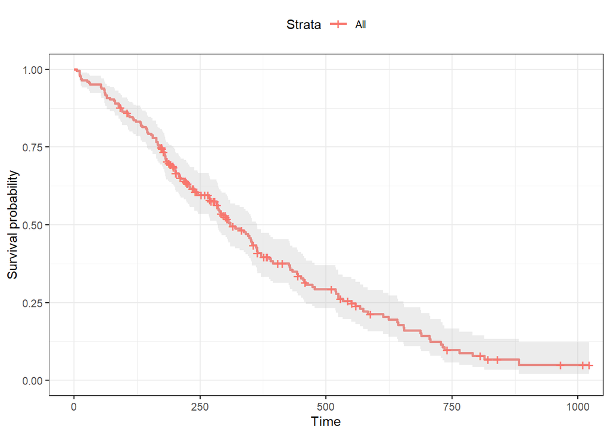

```r
ggsurvplot(fit,conf.int = TRUE,risk.table.col = "strata",ggtheme = theme_bw())
```

### (2) survival time(status==2 : event)에 대해 성별에 따른 Kaplan-Meier 생존함수를 구하고 생존함수 그림을 그리시오.

#### 성별에 따른 Kaplan-Meier 생존함수를 구하면 다음과 같다.

```r
fit1 <- survfit(Surv(time, status==2) ~ sex, data=cancer)
summary(fit1)
```

```
## Call: survfit(formula = Surv(time, status == 2) ~ sex, data = cancer)
##
##                 sex=1
##  time n.risk n.event survival std.err lower 95% CI upper 95% CI
##    11    138       3   0.9783  0.0124       0.9542        1.000
##    12    135       1   0.9710  0.0143       0.9434        0.999
##    13    134       2   0.9565  0.0174       0.9231        0.991
##    15    132       1   0.9493  0.0187       0.9134        0.987
##    26    131       1   0.9420  0.0199       0.9038        0.982
##    30    130       1   0.9348  0.0210       0.8945        0.977
##    31    129       1   0.9275  0.0221       0.8853        0.972
##    53    128       2   0.9130  0.0240       0.8672        0.961
##    54    126       1   0.9058  0.0249       0.8583        0.956
##    59    125       1   0.8986  0.0257       0.8496        0.950
##    60    124       1   0.8913  0.0265       0.8409        0.945
```

[output cut: 142 more lines]

#### 이에 대한 그림은 다음과 같이 그릴 수 있다.

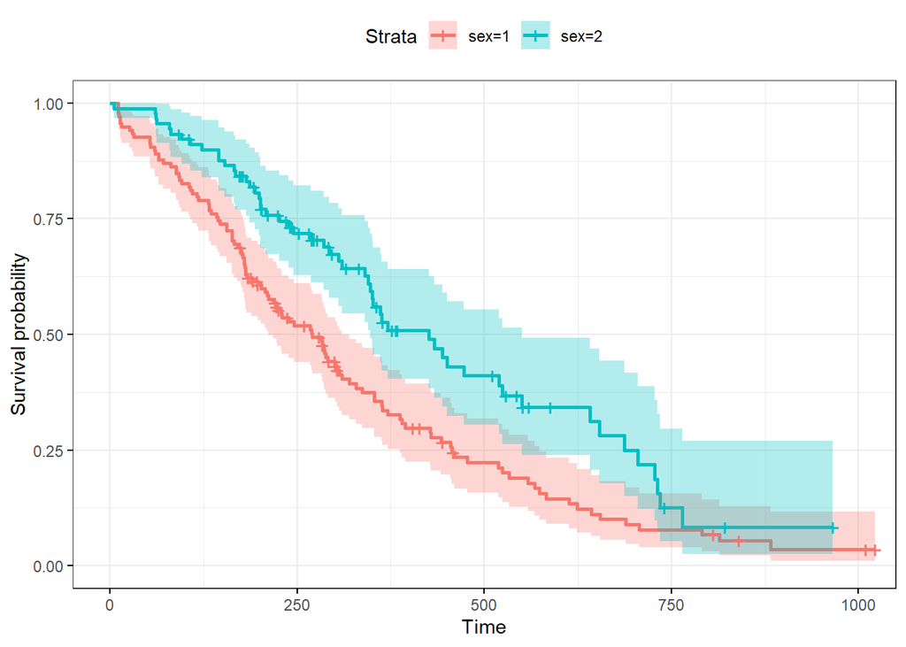

```r
ggsurvplot(fit1,conf.int = TRUE,risk.table.col = "strata",ggtheme = theme_bw())
```

#### 생존함수 그림에서 교차가 일어나지 않고 있으므로 이에 따른 log-rank test를 수행해보면 다음과 같다.

```r
survdiff(Surv(time, status==2) ~ sex, data=cancer, rho=0)
```

```
## Call:
## survdiff(formula = Surv(time, status == 2) ~ sex, data = cancer,
##     rho = 0)
##
##         N Observed Expected (O-E)^2/E (O-E)^2/V
## sex=1 138      112     91.6      4.55      10.3
## sex=2  90       53     73.4      5.68      10.3
##
##  Chisq= 10.3  on 1 degrees of freedom, p= 0.001
```

#### p-value의 값이 0.001이므로 유의수준 0.05보다 작다. 이에 따라 성별에 따른 생존함수는 차이가 있다고 말할 수 있다.

### (3) survival time(status==2 : event)에 대해 공변량을 포함하지 않은 지수회귀모형을 적합하고 추정된 생존함수식을 쓰시오.

```r
a1 <- survreg(Surv(time, status==2) ~ 1, data=cancer, dist="exponential")
summary(a1)
```

```
##
## Call:
## survreg(formula = Surv(time, status == 2) ~ 1, data = cancer,
##     dist = "exponential")
##              Value Std. Error    z      p
## (Intercept) 6.0445     0.0778 77.6 <2e-16
##
## Scale fixed at 1
##
## Exponential distribution
## Loglik(model)= -1162.3   Loglik(intercept only)= -1162.3
## Number of Newton-Raphson Iterations: 4
## n= 228
```

#### 추정된 생존함수식은 다음과 같다.

- $logT=\beta_{0}+\epsilon$ 적합결과 ${\hat{\beta_{0}}}=6.0445$ 이고 검정결과 $p-value<2 * 10 ^{-16}$ 이므로 매우 유의하다. 이에 따른 추정식은 $logT=6.0445$ 이고 생존함수식은 다음과 같다.
- ${\hat{S}} (t)=exp[-t * exp(- {\hat{\beta _{0}}} )]=exp(-e ^{-6.0445} t)$

### (4) survival time(status==2 : event)에 대해 공변량을 포함하지 않은 와이블회귀모형을 적합하고 추정된 생존함수식을 쓰시오.

```r
a2 <- survreg(Surv(time, status==2) ~ 1, data=cancer, dist="weibull")
summary(a2)
```

```
##
## Call:
## survreg(formula = Surv(time, status == 2) ~ 1, data = cancer,
##     dist = "weibull")
##               Value Std. Error      z      p
## (Intercept)  6.0349     0.0591 102.05 <2e-16
## Log(scale)  -0.2752     0.0624  -4.41  1e-05
##
## Scale= 0.759
##
## Weibull distribution
## Loglik(model)= -1153.9   Loglik(intercept only)= -1153.9
## Number of Newton-Raphson Iterations: 6
## n= 228
```

#### 추정된 생존함수식은 다음과 같다.

- $logT= \beta _{0} + \sigma \epsilon$ 적합결과 ${\hat{\beta_{0}}}=6.0349$ 이고 검정결과 $p-value<2 * 10 ^{-16}$ 이므로 매우 유의하다. 또한 이에 따른 추정식은 $logT=6.0349$ 이고 생존함수식은 다음과 같다. ($\kappa=0.759$)
- ${\hat{S}}(t)=exp[-t ^{{\hat{\kappa }}} exp(- {\hat{\beta _{0}}} ) ^{{\hat{\kappa }}} ]=exp[-t ^{0.759} (exp(-6.0349)) ^{0.759} ]$

### (5) survival time(status==2 : event)에 대해 공변량을 모두 포함한 지수회귀모형을 적합하고 추정된 생존함수식을 쓰시오.

#### 변수 중 Institution Code(inst)는 설명변수로서 의미가 없다고 생각하여 제외하였음.

```r
b1 <- survreg(Surv(time, status==2) ~ age+sex+ph.ecog+ph.karno+pat.karno+meal.cal+wt.loss, data=cancer, dist="exponential")
summary(b1)
```

```
##
## Call:
## survreg(formula = Surv(time, status == 2) ~ age + sex + ph.ecog +
##     ph.karno + pat.karno + meal.cal + wt.loss, data = cancer,
##     dist = "exponential")
##                 Value Std. Error     z       p
## (Intercept)  7.53e+00   1.53e+00  4.93 8.4e-07
## age         -8.45e-03   1.13e-02 -0.75  0.4562
## sex2         5.00e-01   2.01e-01  2.49  0.0129
## ph.ecog     -5.95e-01   2.19e-01 -2.71  0.0067
## ph.karno    -1.69e-02   1.13e-02 -1.49  0.1365
## pat.karno    9.19e-03   7.70e-03  1.19  0.2327
## meal.cal     9.81e-06   2.49e-04  0.04  0.9685
## wt.loss      1.01e-02   7.40e-03  1.37  0.1707
##
## Scale fixed at 1
##
## Exponential distribution
## Loglik(model)= -844   Loglik(intercept only)= -854.9
##  Chisq= 21.73 on 7 degrees of freedom, p= 0.0028
## Number of Newton-Raphson Iterations: 4
## n=168 (60 observations deleted due to missingness)
```

#### 분석결과

- 분석결과 변수 sex, ph.ecog에 대해서만 $\alpha=0.05$에서 회귀계수의 검정결과가 유의하다. 그리고 모형 전체에 대해서는 log-likelihood 검정결과 $p-value=0.0028$로 매우 유의함을 알 수 있다.
- ${\hat{S}} (t)=exp[- {\hat{\lambda }} t]=exp[-t*exp(- {\hat{\beta _{0}}} - {\hat{\beta _{1}}} Z _{1} - {\hat{\beta _{2}}} Z _{2} - {\hat{\beta _{3}}} Z _{3} - {\hat{\beta _{4}}} Z _{4} - {\hat{\beta _{5}}} Z _{5} - {\hat{\beta _{6}}} Z _{6} - {\hat{\beta _{7}}} Z _{7} )]$ $=exp[-t*exp(-7.53+0.00845age-0.5sex+0.595ph.ecog+$ $0.0169ph.karno-0.00919pat.karno-0.00000981meal.cal-0.0101wt.loss)]$

### (6) survival time(status==2 : event)에 대해 공변량을 모두 포함한 와이블회귀모형을 적합하고 추정된 생존함수식을 쓰시오.

#### 변수 중 Institution Code(inst)는 설명변수로서 의미가 없다고 생각하여 제외하였음.

```r
b2 <- survreg(Surv(time, status==2) ~ age+sex+ph.ecog+ph.karno+pat.karno+meal.cal+wt.loss, data=cancer, dist="weibull")
summary(b2)
```

```
##
## Call:
## survreg(formula = Surv(time, status == 2) ~ age + sex + ph.ecog +
##     ph.karno + pat.karno + meal.cal + wt.loss, data = cancer,
##     dist = "weibull")
##                 Value Std. Error     z       p
## (Intercept)  7.38e+00   1.05e+00  7.03 2.1e-12
## age         -6.42e-03   7.95e-03 -0.81 0.41983
## sex2         3.87e-01   1.41e-01  2.75 0.00593
## ph.ecog     -5.21e-01   1.53e-01 -3.42 0.00063
## ph.karno    -1.64e-02   7.54e-03 -2.17 0.02984
## pat.karno    8.60e-03   5.53e-03  1.56 0.11979
## meal.cal    -1.25e-05   1.78e-04 -0.07 0.94416
## wt.loss      9.42e-03   5.32e-03  1.77 0.07631
## Log(scale)  -3.63e-01   7.21e-02 -5.03 4.8e-07
##
## Scale= 0.695
##
## Weibull distribution
## Loglik(model)= -833.4   Loglik(intercept only)= -847.6
##  Chisq= 28.48 on 7 degrees of freedom, p= 0.00018
## Number of Newton-Raphson Iterations: 5
## n=168 (60 observations deleted due to missingness)
```

#### 분석결과

- 분석결과 변수 sex, ph.ecog, ph.karno에 대해서만 $\alpha=0.05$에서 회귀계수의 검정결과가 유의하다. 그리고 모형 전체에 대해서는 log-likelihood 검정결과 $p-value=0.00018$로 매우 유의함을 알 수 있다.
- ${\hat{S}} (t)=exp[-( {\hat{\lambda }} t) ^{{\hat{\kappa }}} ]=$ $exp[-t ^{{\hat{\kappa }}} (exp(- {\hat{\beta _{0}}} - {\hat{\beta _{1}}} Z _{1} - {\hat{\beta _{2}}} Z _{2} - {\hat{\beta _{3}}} Z _{3} - {\hat{\beta _{4}}} Z _{4} - {\hat{\beta _{5}}} Z _{5} - {\hat{\beta _{6}}} Z _{6} - {\hat{\beta _{7}}} Z _{7} )) ^{{\hat{\kappa }}} ]$ $=exp[-t ^{0.695} (exp(-7.38+0.00642age-0.387sex+0.521ph.ecog$ $+0.0164ph.karno-0.0086pat.karno-0.0000125meal.cal$ $-0.00942wt.loss)) ^{0.695} ]$

### (7) survival time(status==2 : event)에 대해 공변량을 모두 포함한 지수회귀모형을 적합하고 성별에 따라 추정된 생존함수식을 쓰시오.

#### sex=1 (남자)

- ${\hat{S}} (t)=exp[- {\hat{\lambda }} t]=$ $exp[-t*exp(- {\hat{\beta _{0}}} - {\hat{\beta _{1}}} Z _{1} - {\hat{\beta _{3}}} Z _{3} - {\hat{\beta _{4}}} Z _{4} - {\hat{\beta _{5}}} Z _{5} - {\hat{\beta _{6}}} Z _{6} - {\hat{\beta _{7}}} Z _{7} )]$ $=exp[-t*exp(-7.53+0.00845age+0.595ph.ecog+$ $0.0169ph.karno-0.00919pat.karno-0.00000981meal.cal-0.0101wt.loss)]$

#### sex=2 (여자)

- ${\hat{S}} (t)=exp[- {\hat{\lambda }} t]=$ $exp[-t*exp(- {\hat{\beta _{0}}} - {\hat{\beta _{2}}} - {\hat{\beta _{1}}} Z _{1} - {\hat{\beta _{3}}} Z _{3} - {\hat{\beta _{4}}} Z _{4} - {\hat{\beta _{5}}} Z _{5} - {\hat{\beta _{6}}} Z _{6} - {\hat{\beta _{7}}} Z _{7} )]$ $=exp[-t*exp(-8.03+0.00845age+0.595ph.ecog+$ $0.0169ph.karno-0.00919pat.karno-0.00000981meal.cal-0.0101wt.loss)]$

### (8) survival time(status==2 : event)에 대해 공변량을 모두 포함한 와이블회귀모형을 적합하고 성별에 따라 추정된 생존함수식을 쓰시오.

#### sex=1 (남자)

- ${\hat{S}} (t)=exp[-( {\hat{\lambda }} t) ^{{\hat{\kappa }}} ]=$ $exp[-t ^{{\hat{\kappa }}} (exp(- {\hat{\beta _{0}}} - {\hat{\beta _{1}}} Z _{1} - {\hat{\beta _{3}}} Z _{3} - {\hat{\beta _{4}}} Z _{4} - {\hat{\beta _{5}}} Z _{5} - {\hat{\beta _{6}}} Z _{6} - {\hat{\beta _{7}}} Z _{7} )) ^{{\hat{\kappa }}} ]$ $=exp[-t ^{0.695} (exp(-7.38+0.00642age+0.521ph.ecog+$ $0.0164ph.karno-0.0086pat.karno-0.0000125meal.cal$ $-0.00942wt.loss)) ^{0.695} ]$

#### sex=2 (여자)

- ${\hat{S}} (t)=exp[-( {\hat{\lambda }} t) ^{{\hat{\kappa }}} ]=$ $exp[-t ^{{\hat{\kappa }}} (exp(- {\hat{\beta _{0}}} - {\hat{\beta _{2}}} - {\hat{\beta _{1}}} Z _{1} - {\hat{\beta _{3}}} Z _{3} - {\hat{\beta _{4}}} Z _{4} - {\hat{\beta _{5}}} Z _{5} - {\hat{\beta _{6}}} Z _{6} - {\hat{\beta _{7}}} Z _{7} )) ^{{\hat{\kappa }}} ]$ $=exp[-t ^{0.695} (exp(-7.767+0.00642age+0.521ph.ecog+$ $0.0164ph.karno-0.0086pat.karno-0.0000125meal.cal$ $-0.00942wt.loss)) ^{0.695} ]$

```r
detach(cancer)
```

## 연습문제 9-2) KMsurv 패키지에 내장된 후두암 데이터셋 larynx를 이용해 다음의 분석을 하시오. 포함된 변수는 다음과 같다.

### stage: Stage of disease (1=stage1, 2=stage2, 3=stage3, 4=stage4)

### time: Time to death or on-study time, months

### age: Age at diagnosis of larynx cancer

### diagyr: Year of diagnosis of larynx cancer

### delta: Death indicator (0=alive, 1=dead)

```r
library(KMsurv)
data(larynx)
larynx$stage <- as.factor(larynx$stage)
head(larynx)
```

```
##   stage time age diagyr delta
## 1     1  0.6  77     76     1
## 2     1  1.3  53     71     1
## 3     1  2.4  45     71     1
## 4     1  2.5  57     78     0
## 5     1  3.2  58     74     1
## 6     1  3.2  51     77     0
```

```r
summary(larynx)
```

```
##  stage       time             age            diagyr          delta
##  1:33   Min.   : 0.100   Min.   :41.00   Min.   :70.00   Min.   :0.0000
##  2:17   1st Qu.: 2.000   1st Qu.:57.00   1st Qu.:72.25   1st Qu.:0.0000
##  3:27   Median : 4.000   Median :65.00   Median :74.00   Median :1.0000
##  4:13   Mean   : 4.198   Mean   :64.61   Mean   :74.24   Mean   :0.5556
##         3rd Qu.: 6.200   3rd Qu.:72.00   3rd Qu.:76.00   3rd Qu.:1.0000
##         Max.   :10.700   Max.   :86.00   Max.   :78.00   Max.   :1.0000
```

### (1) time(delta==1 : event)에 대해 Kaplan-Meier 생존함수를 구하고 생존함수 그림을 그리시오.

```r
attach(larynx)
Surv(time, delta==1)
```

```
##  [1]  0.6   1.3   2.4   2.5+  3.2   3.2+  3.3   3.3+  3.5   3.5   4.0   4.0
## [13]  4.3   4.5+  4.5+  5.3   5.5+  5.9+  5.9+  6.0   6.1+  6.2+  6.4   6.5
## [25]  6.5+  6.7+  7.0+  7.4   7.4+  8.1+  8.1+  9.6+ 10.7+  0.2   1.8   2.0
## [37]  2.2+  2.6+  3.3+  3.6   3.6+  4.0   4.3+  4.3+  5.0+  6.2   7.0   7.5+
## [49]  7.6+  9.3+  0.3   0.3   0.5   0.7   0.8   1.0   1.3   1.6   1.8   1.9
## [61]  1.9   3.2   3.5   3.7+  4.5+  4.8+  4.8+  5.0   5.0+  5.1+  6.3   6.4
## [73]  6.5+  7.8   8.0+  9.3+ 10.1+  0.1   0.3   0.4   0.8   0.8   1.0   1.5
## [85]  2.0   2.3   2.9+  3.6   3.8   4.3+
```

#### 동점이 일부 있는 것으로 보임.

#### Kaplan-Meier 생존함수를 구하면 다음과 같다.

```r
fit <- survfit(Surv(time, delta==1) ~ 1, data=larynx)
summary(fit)
```

```
## Call: survfit(formula = Surv(time, delta == 1) ~ 1, data = larynx)
##
##  time n.risk n.event survival std.err lower 95% CI upper 95% CI
##   0.1     90       1    0.989  0.0110        0.967        1.000
##   0.2     89       1    0.978  0.0155        0.948        1.000
##   0.3     88       3    0.944  0.0241        0.898        0.993
##   0.4     85       1    0.933  0.0263        0.883        0.986
##   0.5     84       1    0.922  0.0282        0.869        0.979
##   0.6     83       1    0.911  0.0300        0.854        0.972
##   0.7     82       1    0.900  0.0316        0.840        0.964
##   0.8     81       3    0.867  0.0358        0.799        0.940
##   1.0     78       2    0.844  0.0382        0.773        0.923
##   1.3     76       2    0.822  0.0403        0.747        0.905
##   1.5     74       1    0.811  0.0413        0.734        0.896
##   1.6     73       1    0.800  0.0422        0.721        0.887
##   1.8     72       2    0.778  0.0438        0.696        0.869
##   1.9     70       2    0.756  0.0453        0.672        0.850
##   2.0     68       2    0.733  0.0466        0.647        0.831
##   2.3     65       1    0.722  0.0472        0.635        0.821
##   2.4     64       1    0.711  0.0478        0.623        0.811
##   3.2     60       2    0.687  0.0491        0.597        0.790
##   3.3     57       1    0.675  0.0497        0.584        0.780
##   3.5     54       3    0.638  0.0514        0.544        0.747
##   3.6     51       2    0.613  0.0524        0.518        0.724
##   3.8     47       1    0.599  0.0528        0.504        0.713
##   4.0     46       3    0.560  0.0540        0.464        0.677
##   4.3     43       1    0.547  0.0543        0.451        0.665
##   5.0     34       1    0.531  0.0550        0.434        0.651
##   5.3     30       1    0.514  0.0560        0.415        0.636
##   6.0     26       1    0.494  0.0572        0.394        0.620
##   6.2     24       1    0.473  0.0584        0.372        0.603
##   6.3     22       1    0.452  0.0596        0.349        0.585
##   6.4     21       2    0.409  0.0612        0.305        0.548
##   6.5     19       1    0.387  0.0616        0.283        0.529
##   7.0     15       1    0.361  0.0627        0.257        0.508
##   7.4     13       1    0.334  0.0637        0.229        0.485
##   7.8      9       1    0.297  0.0666        0.191        0.460
```

#### 이에 대한 그림은 다음과 같이 그릴 수 있다.

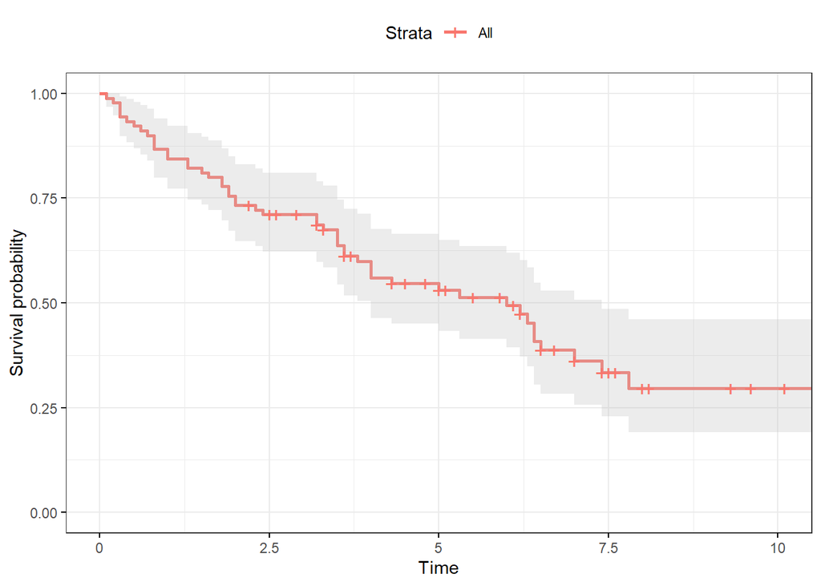

```r
ggsurvplot(fit,conf.int = TRUE,risk.table.col = "strata",ggtheme = theme_bw())
```

### (2) time(delta==1 : event)에 대해 병기(stage)에 따른 Kaplan-Meier 생존함수를 구하고 생존함수 그림을 그리시오.

#### 병기에 따른 Kaplan-Meier 생존함수를 구하면 다음과 같다.

```r
fit1 <- survfit(Surv(time, delta==1) ~ stage, data=larynx)
summary(fit1)
```

```
## Call: survfit(formula = Surv(time, delta == 1) ~ stage, data = larynx)
##
##                 stage=1
##  time n.risk n.event survival std.err lower 95% CI upper 95% CI
##   0.6     33       1    0.970  0.0298        0.913        1.000
##   1.3     32       1    0.939  0.0415        0.861        1.000
##   2.4     31       1    0.909  0.0500        0.816        1.000
##   3.2     29       1    0.878  0.0573        0.772        0.998
##   3.3     27       1    0.845  0.0637        0.729        0.980
##   3.5     25       2    0.778  0.0744        0.645        0.938
##   4.0     23       2    0.710  0.0819        0.566        0.890
##   4.3     21       1    0.676  0.0847        0.529        0.864
##   5.3     18       1    0.639  0.0879        0.488        0.836
##   6.0     14       1    0.593  0.0927        0.436        0.806
##   6.4     11       1    0.539  0.0987        0.377        0.772
##   6.5     10       1    0.485  0.1025        0.321        0.734
##   7.4      6       1    0.404  0.1129        0.234        0.699
##
##                 stage=2
##  time n.risk n.event survival std.err lower 95% CI upper 95% CI
##   0.2     17       1    0.941  0.0571        0.836        1.000
##   1.8     16       1    0.882  0.0781        0.742        1.000
##   2.0     15       1    0.824  0.0925        0.661        1.000
##   3.6     11       1    0.749  0.1103        0.561        0.999
##   4.0      9       1    0.665  0.1255        0.460        0.963
##   6.2      5       1    0.532  0.1557        0.300        0.945
##   7.0      4       1    0.399  0.1641        0.178        0.894
##
##                 stage=3
##  time n.risk n.event survival std.err lower 95% CI upper 95% CI
##   0.3     27       2    0.926  0.0504        0.832        1.000
##   0.5     25       1    0.889  0.0605        0.778        1.000
##   0.7     24       1    0.852  0.0684        0.728        0.997
##   0.8     23       1    0.815  0.0748        0.681        0.975
##   1.0     22       1    0.778  0.0800        0.636        0.952
##   1.3     21       1    0.741  0.0843        0.593        0.926
##   1.6     20       1    0.704  0.0879        0.551        0.899
##   1.8     19       1    0.667  0.0907        0.511        0.870
##   1.9     18       2    0.593  0.0946        0.433        0.810
##   3.2     16       1    0.556  0.0956        0.396        0.778
##   3.5     15       1    0.519  0.0962        0.361        0.746
##   5.0     10       1    0.467  0.0995        0.307        0.709
##   6.3      7       1    0.400  0.1053        0.239        0.670
##   6.4      6       1    0.333  0.1068        0.178        0.625
##   7.8      4       1    0.250  0.1078        0.107        0.582
##
##                 stage=4
##  time n.risk n.event survival std.err lower 95% CI upper 95% CI
##   0.1     13       1    0.923  0.0739       0.7890        1.000
##   0.3     12       1    0.846  0.1001       0.6711        1.000
##   0.4     11       1    0.769  0.1169       0.5711        1.000
##   0.8     10       2    0.615  0.1349       0.4004        0.946
##   1.0      8       1    0.538  0.1383       0.3255        0.891
##   1.5      7       1    0.462  0.1383       0.2566        0.830
##   2.0      6       1    0.385  0.1349       0.1934        0.765
##   2.3      5       1    0.308  0.1280       0.1361        0.695
##   3.6      3       1    0.205  0.1196       0.0654        0.643
##   3.8      2       1    0.103  0.0940       0.0170        0.618
```

#### 이에 대한 그림은 다음과 같이 그릴 수 있다.

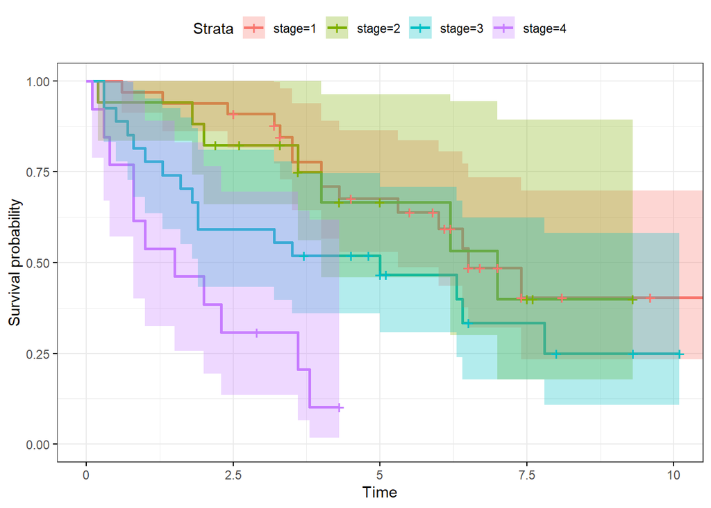

```r
ggsurvplot(fit1,conf.int = TRUE,risk.table.col = "strata",ggtheme = theme_bw())
```

#### 생존함수 그림에서 일부 교차가 일어나고 있으므로 이에 따른 Peto & Peto test를 수행해보면 다음과 같다.

```r
survdiff(Surv(time, delta==1) ~ stage, data=larynx, rho=1)
```

```
## Call:
## survdiff(formula = Surv(time, delta == 1) ~ stage, data = larynx,
##     rho = 1)
##
##          N Observed Expected (O-E)^2/E (O-E)^2/V
## stage=1 33     9.26    15.78     2.694      6.48
## stage=2 17     4.66     7.18     0.884      1.47
## stage=3 27    12.77    10.06     0.730      1.35
## stage=4 13     9.15     2.82    14.219     18.78
##
##  Chisq= 23.1  on 3 degrees of freedom, p= 4e-05
```

#### p-value의 값이 4*10^(-5)이므로 유의수준 0.05보다 작다. 이에 따라 stage에 따른 생존함수는 차이가 있다고 말할 수 있다.

### (3) time(delta==1 : event)에 대해 공변량을 포함하지 않은 지수회귀모형을 적합하고 추정된 생존함수식을 쓰시오.

```r
a1 <- survreg(Surv(time, delta==1) ~ 1, data=larynx, dist="exponential")
summary(a1)
```

```
##
## Call:
## survreg(formula = Surv(time, delta == 1) ~ 1, data = larynx,
##     dist = "exponential")
##             Value Std. Error    z      p
## (Intercept) 2.022      0.141 14.3 <2e-16
##
## Scale fixed at 1
##
## Exponential distribution
## Loglik(model)= -151.1   Loglik(intercept only)= -151.1
## Number of Newton-Raphson Iterations: 4
## n= 90
```

#### 추정된 생존함수식은 다음과 같다.

- $logT=\beta_{0}+\epsilon$ 적합결과 ${\hat{\beta_{0}}}=2.022$ 이고 검정결과 $p-value<2 * 10 ^{-16}$ 이므로 매우 유의하다. 이에 따른 추정식은 $logT=2.022$ 이고 생존함수식은 다음과 같다.
- ${\hat{S}} (t)=exp[-t * exp(- {\hat{\beta _{0}}} )]=exp(-e ^{-2.022} t)$

### (4) time(delta==1 : event)에 대해 공변량을 포함하지 않은 와이블회귀모형을 적합하고 추정된 생존함수식을 쓰시오.

```r
a2 <- survreg(Surv(time, delta==1) ~ 1, data=larynx, dist="weibull")
summary(a2)
```

```
##
## Call:
## survreg(formula = Surv(time, delta == 1) ~ 1, data = larynx,
##     dist = "weibull")
##               Value Std. Error     z      p
## (Intercept)  2.0169     0.1465 13.77 <2e-16
## Log(scale)  -0.0148     0.1243 -0.12   0.91
##
## Scale= 0.985
##
## Weibull distribution
## Loglik(model)= -151.1   Loglik(intercept only)= -151.1
## Number of Newton-Raphson Iterations: 5
## n= 90
```

#### 추정된 생존함수식은 다음과 같다.

- $logT= \beta _{0} + \sigma \epsilon$ 적합결과 ${\hat{\beta_{0}}}=2.0169$ 이고 검정결과 $p-value<2 * 10 ^{-16}$ 이므로 매우 유의하다. 또한 이에 따른 추정식은 $logT=2.0169$ 이고 생존함수식은 다음과 같다. ($\kappa=0.985$)
- ${\hat{S}}(t)=exp[-t ^{{\hat{\kappa }}} exp(- {\hat{\beta _{0}}} ) ^{{\hat{\kappa }}} ]=exp[-t ^{0.985} (exp(-2.0169)) ^{0.985} ]$

### (5) time(delta==1 : event)에 대해 공변량을 모두 포함한 지수회귀모형을 적합하고 추정된 생존함수식을 쓰시오.

```r
b1 <- survreg(Surv(time, delta==1) ~ stage+age+diagyr, data=larynx, dist="exponential")
summary(b1)
```

```
##
## Call:
## survreg(formula = Surv(time, delta == 1) ~ stage + age + diagyr,
##     data = larynx, dist = "exponential")
##               Value Std. Error     z       p
## (Intercept)  1.1781     5.3730  0.22   0.826
## stage2      -0.1722     0.4631 -0.37   0.710
## stage3      -0.6536     0.3553 -1.84   0.066
## stage4      -1.7015     0.4212 -4.04 5.4e-05
## age         -0.0191     0.0143 -1.33   0.182
## diagyr       0.0346     0.0710  0.49   0.626
##
## Scale fixed at 1
##
## Exponential distribution
## Loglik(model)= -141.8   Loglik(intercept only)= -151.1
##  Chisq= 18.68 on 5 degrees of freedom, p= 0.0022
## Number of Newton-Raphson Iterations: 4
## n= 90
```

#### 분석결과

- 분석결과 변수 stage에 대해서만 $\alpha=0.05$에서 회귀계수의 검정결과가 유의하다. 그리고 모형 전체에 대해서는 log-likelihood 검정결과 $p-value=0.0022$로 매우 유의함을 알 수 있다.
- ${\hat{S}} (t)=exp[- {\hat{\lambda }} t]=exp[-t*exp(- {\hat{\beta _{0}}} - {\hat{\beta _{1}}} Z _{1} - {\hat{\beta _{2}}} Z _{2} - {\hat{\beta _{3}}} Z _{3} - {\hat{\beta _{4}}} Z _{4} - {\hat{\beta _{5}}} Z _{5} )]$ $=exp[-t*exp(-1.1781+0.1722stage2+0.6536stage3+1.7015stage4$ $+0.0191age-0.0346diagyr)]$

### (6) time(delta==1 : event)에 대해 공변량을 모두 포함한 와이블회귀모형을 적합하고 추정된 생존함수식을 쓰시오. (stage를 연속형 변수로 간주)

```r
larynx$stage <- as.numeric(larynx$stage)
attach(larynx)
b2 <- survreg(Surv(time, delta==1) ~ stage+age+diagyr, data=larynx, dist="weibull")
summary(b2)
```

```
##
## Call:
## survreg(formula = Surv(time, delta == 1) ~ stage + age + diagyr,
##     data = larynx, dist = "weibull")
##                Value Std. Error     z       p
## (Intercept)  4.30743    4.82494  0.89 0.37199
## stage       -0.47084    0.13357 -3.53 0.00042
## age         -0.02176    0.01331 -1.63 0.10216
## diagyr       0.00199    0.06499  0.03 0.97555
## Log(scale)  -0.08989    0.12504 -0.72 0.47221
##
## Scale= 0.914
##
## Weibull distribution
## Loglik(model)= -142.7   Loglik(intercept only)= -151.1
##  Chisq= 16.86 on 3 degrees of freedom, p= 0.00076
## Number of Newton-Raphson Iterations: 5
## n= 90
```

#### 분석결과

- 분석결과 변수 stage에 대해서만 $\alpha=0.05$에서 회귀계수의 검정결과가 유의하다. 그리고 모형 전체에 대해서는 log-likelihood 검정결과 $p-value=0.00076$로 매우 유의함을 알 수 있다.
- ${\hat{S}} (t)=exp[-( {\hat{\lambda }} t) ^{{\hat{\kappa }}} ]=$ $exp[-t ^{{\hat{\kappa }}} (exp(- {\hat{\beta _{0}}} - {\hat{\beta _{1}}} Z _{1} - {\hat{\beta _{2}}} Z _{2} - {\hat{\beta _{3}}} Z _{3} )) ^{{\hat{\kappa }}} ]$ $=exp[-t ^{0.914} (exp(-4.30743+0.47084stage+0.02176age-0.00199diagyr)) ^{0.914} ]$

### (7) time(delta==1 : event)에 대해 공변량을 모두 포함한 와이블회귀모형을 적합하고 병기(stage)에 따라 추정된 생존함수식을 쓰시오. (stage를 연속형 변수로 간주)

#### stage 1

- ${\hat{S}} (t)=exp[-( {\hat{\lambda }} t) ^{{\hat{\kappa }}} ]=$ $exp[-t ^{{\hat{\kappa }}} (exp(- {\hat{\beta _{0}}} - {\hat{\beta _{1}}} *1 - {\hat{\beta _{2}}} Z _{2} - {\hat{\beta _{3}}} Z _{3} )) ^{{\hat{\kappa }}} ]$ $=exp[-t ^{0.914} (exp(-4.30743+0.47084*1+0.02176age-0.00199diagyr)) ^{0.914} ]$ $=exp[-t ^{0.914} (exp(-3.83659+0.02176age-0.00199diagyr)) ^{0.914}]$

#### stage 2

- ${\hat{S}} (t)=exp[-( {\hat{\lambda }} t) ^{{\hat{\kappa }}} ]=$ $exp[-t ^{{\hat{\kappa }}} (exp(- {\hat{\beta _{0}}} - {\hat{\beta _{1}}} *2 - {\hat{\beta _{2}}} Z _{2} - {\hat{\beta _{3}}} Z _{3} )) ^{{\hat{\kappa }}} ]$ $=exp[-t ^{0.914} (exp(-4.30743+0.47084*2+0.02176age-0.00199diagyr)) ^{0.914} ]$ $=exp[-t ^{0.914} (exp(-3.36575+0.02176age-0.00199diagyr)) ^{0.914}]$

#### stage 3

- ${\hat{S}} (t)=exp[-( {\hat{\lambda }} t) ^{{\hat{\kappa }}} ]=$ $exp[-t ^{{\hat{\kappa }}} (exp(- {\hat{\beta _{0}}} - {\hat{\beta _{1}}} *3 - {\hat{\beta _{2}}} Z _{2} - {\hat{\beta _{3}}} Z _{3} )) ^{{\hat{\kappa }}} ]$ $=exp[-t ^{0.914} (exp(-4.30743+0.47084*3+0.02176age-0.00199diagyr)) ^{0.914} ]$ $=exp[-t ^{0.914} (exp(-2.89491+0.02176age-0.00199diagyr)) ^{0.914}]$

#### stage 4

- ${\hat{S}} (t)=exp[-( {\hat{\lambda }} t) ^{{\hat{\kappa }}} ]=$ $exp[-t ^{{\hat{\kappa }}} (exp(- {\hat{\beta _{0}}} - {\hat{\beta _{1}}} *4 - {\hat{\beta _{2}}} Z _{2} - {\hat{\beta _{3}}} Z _{3} )) ^{{\hat{\kappa }}} ]$ $=exp[-t ^{0.914} (exp(-4.30743+0.47084*4+0.02176age-0.00199diagyr)) ^{0.914} ]$ $=exp[-t ^{0.914} (exp(-2.42407+0.02176age-0.00199diagyr)) ^{0.914}]$

### (8) time(delta==1 : event)에 대해 공변량을 모두 포함한 와이블회귀모형을 적합하고 추정된 생존함수식을 쓰시오. (stage를 이산형 변수로 간주)

```r
larynx$stage <- as.factor(larynx$stage)
attach(larynx)
b3 <- survreg(Surv(time, delta==1) ~ stage+age+diagyr, data=larynx, dist="weibull")
summary(b3)
```

```
##
## Call:
## survreg(formula = Surv(time, delta == 1) ~ stage + age + diagyr,
##     data = larynx, dist = "weibull")
##               Value Std. Error     z       p
## (Intercept)  2.1080     4.9162  0.43   0.668
## stage2      -0.1615     0.4133 -0.39   0.696
## stage3      -0.5928     0.3232 -1.83   0.067
## stage4      -1.5872     0.3952 -4.02 5.9e-05
## age         -0.0172     0.0129 -1.33   0.182
## diagyr       0.0192     0.0656  0.29   0.769
## Log(scale)  -0.1146     0.1254 -0.91   0.361
##
## Scale= 0.892
##
## Weibull distribution
## Loglik(model)= -141.4   Loglik(intercept only)= -151.1
##  Chisq= 19.46 on 5 degrees of freedom, p= 0.0016
## Number of Newton-Raphson Iterations: 5
## n= 90
```

#### 분석결과

- 분석결과 변수 stage에 대해서만 $\alpha=0.05$에서 회귀계수의 검정결과가 유의하다. 그리고 모형 전체에 대해서는 log-likelihood 검정결과 $p-value=0.0016$으로 매우 유의함을 알 수 있다.
- ${\hat{S}} (t)=exp[-( {\hat{\lambda }} t) ^{{\hat{\kappa }}} ]=$ $exp[-t ^{{\hat{\kappa }}} (exp(- {\hat{\beta _{0}}} - {\hat{\beta _{1}}} Z _{1} - {\hat{\beta _{2}}} Z _{2} - {\hat{\beta _{3}}} Z _{3} - {\hat{\beta _{4}}} Z _{4} - {\hat{\beta _{5}}} Z _{5} )) ^{{\hat{\kappa }}} ]$ $=exp[-t ^{0.892} (exp(-2.1080+0.1615stage2+0.5928stage3$ $+1.5872stage4+0.0172age-0.0192diagyr)) ^{0.892} ]$

### (9) time(delta==1 : event)에 대해 공변량을 모두 포함한 와이블회귀모형을 적합하고 병기(stage)에 따라 추정된 생존함수식을 쓰시오. (stage를 이산형 변수로 간주)

#### stage 1

- ${\hat{S}} (t)=exp[-( {\hat{\lambda }} t) ^{{\hat{\kappa }}} ]=$ $exp[-t ^{{\hat{\kappa }}} (exp(- {\hat{\beta _{0}}} - {\hat{\beta _{4}}} Z _{4} - {\hat{\beta _{5}}} Z _{5} )) ^{{\hat{\kappa }}} ]$ $=exp[-t ^{0.892} (exp(-2.1080+0.0172age-0.0192diagyr)) ^{0.892} ]$

#### stage 2

- ${\hat{S}} (t)=exp[-( {\hat{\lambda }} t) ^{{\hat{\kappa }}} ]=$ $exp[-t ^{{\hat{\kappa }}} (exp(- {\hat{\beta _{0}}} - {\hat{\beta _{1}}} - {\hat{\beta _{4}}} Z _{4} - {\hat{\beta _{5}}} Z _{5} )) ^{{\hat{\kappa }}} ]$ $=exp[-t ^{0.892} (exp(-1.9465+0.0172age-0.0192diagyr)) ^{0.892} ]$

#### stage 3

- ${\hat{S}} (t)=exp[-( {\hat{\lambda }} t) ^{{\hat{\kappa }}} ]=$ $exp[-t ^{{\hat{\kappa }}} (exp(- {\hat{\beta _{0}}} - {\hat{\beta _{2}}} - {\hat{\beta _{4}}} Z _{4} - {\hat{\beta _{5}}} Z _{5} )) ^{{\hat{\kappa }}} ]$ $=exp[-t ^{0.892} (exp(-1.5152+0.0172age-0.0192diagyr)) ^{0.892} ]$

#### stage 4

- ${\hat{S}} (t)=exp[-( {\hat{\lambda }} t) ^{{\hat{\kappa }}} ]=$ $exp[-t ^{{\hat{\kappa }}} (exp(- {\hat{\beta _{0}}} - {\hat{\beta _{3}}} - {\hat{\beta _{4}}} Z _{4} - {\hat{\beta _{5}}} Z _{5} )) ^{{\hat{\kappa }}} ]$ $=exp[-t ^{0.892} (exp(-0.5208+0.0172age-0.0192diagyr)) ^{0.892} ]$

### (10) 위 데이터에 대해 적절한 회귀모형을 제안하시오.

#### AIC(Akaike’s Information Criterion) 기준으로 모형을 살펴보면 다음과 같다.

```r
a1
```

```
## Call:
## survreg(formula = Surv(time, delta == 1) ~ 1, data = larynx,
##     dist = "exponential")
##
## Coefficients:
## (Intercept)
##    2.022342
##
## Scale fixed at 1
##
## Loglik(model)= -151.1   Loglik(intercept only)= -151.1
## n= 90
```

```r
extractAIC(a1)
```

```
## [1]   1.0000 304.2342
```

```r
a2
```

```
## Call:
## survreg(formula = Surv(time, delta == 1) ~ 1, data = larynx,
##     dist = "weibull")
##
## Coefficients:
## (Intercept)
##    2.016891
##
## Scale= 0.9853167
##
## Loglik(model)= -151.1   Loglik(intercept only)= -151.1
## n= 90
```

```r
extractAIC(a2)
```

```
## [1]   2.0000 306.2201
```

```r
b1
```

```
## Call:
## survreg(formula = Surv(time, delta == 1) ~ stage + age + diagyr,
##     data = larynx, dist = "exponential")
##
## Coefficients:
## (Intercept)      stage2      stage3      stage4         age      diagyr
##  1.17814863 -0.17220504 -0.65361599 -1.70152124 -0.01905035  0.03458908
##
## Scale fixed at 1
##
## Loglik(model)= -141.8   Loglik(intercept only)= -151.1
##  Chisq= 18.68 on 5 degrees of freedom, p= 0.00221
## n= 90
```

```r
extractAIC(b1)
```

```
## [1]   6.0000 295.5582
```

```r
b2
```

```
## Call:
## survreg(formula = Surv(time, delta == 1) ~ stage + age + diagyr,
##     data = larynx, dist = "weibull")
##
## Coefficients:
##  (Intercept)        stage          age       diagyr
##  4.307434363 -0.470837022 -0.021760384  0.001991844
##
## Scale= 0.914034
##
## Loglik(model)= -142.7   Loglik(intercept only)= -151.1
##  Chisq= 16.86 on 3 degrees of freedom, p= 0.000757
## n= 90
```

```r
extractAIC(b2)
```

```
## [1]   5.0000 295.3645
```

```r
b3
```

```
## Call:
## survreg(formula = Surv(time, delta == 1) ~ stage + age + diagyr,
##     data = larynx, dist = "weibull")
##
## Coefficients:
## (Intercept)      stage2      stage3      stage4         age      diagyr
##  2.10803755 -0.16152226 -0.59281996 -1.58720466 -0.01721711  0.01924785
##
## Scale= 0.8917158
##
## Loglik(model)= -141.4   Loglik(intercept only)= -151.1
##  Chisq= 19.46 on 5 degrees of freedom, p= 0.00158
## n= 90
```

```r
extractAIC(b3)
```

```
## [1]   7.0000 296.7593
```

#### 분석결과 stage를 연속형 변수로 간주하고 모든 공변량을 포함한 와이블회귀모형의 AIC값이 가장 작으므로 이 모형을 제안한다. 하지만 그 외의 모형들 중 공변량을 포함한 모형의 AIC값도 거의 비슷하게 나옴을 확인할 수 있다.

### (11) time(delta==1 : event)에 대해 공변량을 모두 포함한 Cox 비례위험모형을 적합하고 추정된 생존함수식을 쓰시오. (stage를 연속형 변수로 간주)

```r
larynx$stage <- as.numeric(larynx$stage)
attach(larynx)
library(survival)
c1 <- coxph(Surv(time, delta==1) ~ stage+age+diagyr, data=larynx, ties="efron")
summary(c1)
```

```
## Call:
## coxph(formula = Surv(time, delta == 1) ~ stage + age + diagyr,
##     data = larynx, ties = "efron")
##
##   n= 90, number of events= 50
##
##             coef exp(coef)  se(coef)      z Pr(>|z|)
## stage   0.501901  1.651859  0.141041  3.559 0.000373 ***
## age     0.022752  1.023013  0.014464  1.573 0.115710
## diagyr -0.001703  0.998298  0.074766 -0.023 0.981825
## ---
## Signif. codes:  0 '***' 0.001 '**' 0.01 '*' 0.05 '.' 0.1 ' ' 1
##
##        exp(coef) exp(-coef) lower .95 upper .95
## stage     1.6519     0.6054    1.2529     2.178
## age       1.0230     0.9775    0.9944     1.052
## diagyr    0.9983     1.0017    0.8622     1.156
##
## Concordance= 0.677  (se = 0.039 )
## Likelihood ratio test= 15.82  on 3 df,   p=0.001
## Wald test            = 15.9  on 3 df,   p=0.001
## Score (logrank) test = 16.66  on 3 df,   p=8e-04
```

#### 분석결과

- 분석결과 변수 stage에 대해서만 $\alpha=0.05$에서 회귀계수의 검정결과가 유의하다. 그리고 모형 전체에 대해서는 Likelihood ratio test 결과 $p-value=0.001$로 매우 유의함을 알 수 있다.
- ${\hat{h}} (t|Z)=h _{0} (t)exp( {\hat{\beta _{1}}} Z _{1} + {\hat{\beta _{2}}} Z _{2} + {\hat{\beta _{3}}} Z _{3} )$ $=h _{0} (t)exp(0.501901stage+0.022752age-0.001703diagyr)$

### (12) time(delta==1 : event)에 대해 공변량을 모두 포함한 Cox 비례위험모형을 적합하고 추정된 생존함수식을 쓰시오. (stage를 이산형 변수로 간주)

```r
larynx$stage <- as.factor(larynx$stage)
attach(larynx)
c2 <- coxph(Surv(time, delta==1) ~ stage+age+diagyr, data=larynx, ties="efron")
summary(c2)
```

```
## Call:
## coxph(formula = Surv(time, delta == 1) ~ stage + age + diagyr,
##     data = larynx, ties = "efron")
##
##   n= 90, number of events= 50
##
##            coef exp(coef) se(coef)      z Pr(>|z|)
## stage2  0.15164   1.16375  0.46481  0.326   0.7442
## stage3  0.64473   1.90546  0.35619  1.810   0.0703 .
## stage4  1.73211   5.65255  0.43596  3.973 7.09e-05 ***
## age     0.01869   1.01887  0.01433  1.304   0.1922
## diagyr -0.01819   0.98198  0.07646 -0.238   0.8120
## ---
## Signif. codes:  0 '***' 0.001 '**' 0.01 '*' 0.05 '.' 0.1 ' ' 1
##
##        exp(coef) exp(-coef) lower .95 upper .95
## stage2     1.164     0.8593    0.4680     2.894
## stage3     1.905     0.5248    0.9480     3.830
## stage4     5.653     0.1769    2.4052    13.284
## age        1.019     0.9815    0.9906     1.048
## diagyr     0.982     1.0184    0.8453     1.141
##
## Concordance= 0.674  (se = 0.039 )
## Likelihood ratio test= 18.37  on 5 df,   p=0.003
## Wald test            = 21.2  on 5 df,   p=7e-04
## Score (logrank) test = 24.84  on 5 df,   p=1e-04
```

- 분석결과 변수 stage에 대해서만 $\alpha=0.05$에서 회귀계수의 검정결과가 유의하다. 그리고 모형 전체에 대해서는 Likelihood ratio test 결과 $p-value=0.003$로 매우 유의함을 알 수 있다.
- ${\hat{h}} (t|Z)=h _{0} (t)exp( {\hat{\beta _{1}}} Z _{1} + {\hat{\beta _{2}}} Z _{2} + {\hat{\beta _{3}}} Z _{3} + {\hat{\beta _{4}}} Z _{4} + {\hat{\beta _{5}}} Z _{5} )$ $=h _{0} (t)exp(0.15164stage2+0.64473stage3+1.73211stage4$ $+0.01869age-0.01819diagyr)$

### (13) time(delta==1 : event)에 대해 적절한 Cox 비례위험모형을 적합하고 위험함수식을 쓰시오.

#### (12)에서 적합한 모형에서 AIC 기준으로 변수를 선택하면 다음과 같다.

```r
library(MASS)
c2_select <- stepAIC(c2,direction="both",trace=TRUE)
```

```
## Start:  AIC=385.36
## Surv(time, delta == 1) ~ stage + age + diagyr
##
##          Df    AIC
## - diagyr  1 383.41
## - age     1 385.10
## <none>      385.36
## - stage   3 394.87
##
## Step:  AIC=383.41
## Surv(time, delta == 1) ~ stage + age
##
##          Df    AIC
## - age     1 383.24
## <none>      383.41
## + diagyr  1 385.36
## - stage   3 393.10
##
## Step:  AIC=383.24
## Surv(time, delta == 1) ~ stage
##
##          Df    AIC
## <none>      383.24
## + age     1 383.41
## + diagyr  1 385.10
## - stage   3 393.73
```

```r
summary(c2_select)
```

```
## Call:
## coxph(formula = Surv(time, delta == 1) ~ stage, data = larynx,
##     ties = "efron")
##
##   n= 90, number of events= 50
##
##           coef exp(coef) se(coef)     z Pr(>|z|)
## stage2 0.06481   1.06696  0.45843 0.141   0.8876
## stage3 0.61481   1.84930  0.35519 1.731   0.0835 .
## stage4 1.73490   5.66838  0.41939 4.137 3.52e-05 ***
## ---
## Signif. codes:  0 '***' 0.001 '**' 0.01 '*' 0.05 '.' 0.1 ' ' 1
##
##        exp(coef) exp(-coef) lower .95 upper .95
## stage2     1.067     0.9372    0.4344      2.62
## stage3     1.849     0.5407    0.9219      3.71
## stage4     5.668     0.1764    2.4916     12.90
##
## Concordance= 0.668  (se = 0.037 )
## Likelihood ratio test= 16.49  on 3 df,   p=9e-04
## Wald test            = 19.24  on 3 df,   p=2e-04
## Score (logrank) test = 22.88  on 3 df,   p=4e-05
```

#### 결과적으로 stage 변수만 포함한 모형이 선택되었다.

- ${\hat{h}} (t|Z)=h _{0} (t)exp( {\hat{\beta _{1}}} Z _{1} + {\hat{\beta _{2}}} Z _{2} + {\hat{\beta _{3}}} Z _{3} )$ $=h _{0} (t)exp(0.06481stage2+0.61481stage3+1.73490stage4)$

```r
detach(larynx)
```

## 연습문제 9-3) 다음의 데이터는 해당 온도(temperature)에서 전기 모터의 고장까지의 시간(hours)이다.

```r
electric <- tibble(hours=c(8064,1764,2772,3444,3542,3780,4860,5196,5448,408,1344,1440,1680,408,504,528),censor=c(0,1,1,1,1,1,1,1,0,1,1,1,0,1,1,0),temperature=c(150,170,170,170,170,170,170,170,170,190,190,190,190,220,220,220))
head(electric)
```

```
## # A tibble: 6 x 3
##   hours censor temperature
##   <dbl>  <dbl>       <dbl>
## 1  8064      0         150
## 2  1764      1         170
## 3  2772      1         170
## 4  3444      1         170
## 5  3542      1         170
## 6  3780      1         170
```

### (1) hours(censor==1 : event)에 대해 Kaplan-Meier 생존함수를 구하고 생존함수 그림을 그리시오.

```r
attach(electric)
Surv(hours, censor==1)
```

```
##  [1] 8064+ 1764  2772  3444  3542  3780  4860  5196  5448+  408  1344  1440
## [13] 1680+  408   504   528+
```

#### Kaplan-Meier 생존함수를 구하면 다음과 같다.

```r
fit <- survfit(Surv(hours, censor==1) ~ 1, data=electric)
summary(fit)
```

```
## Call: survfit(formula = Surv(hours, censor == 1) ~ 1, data = electric)
##
##  time n.risk n.event survival std.err lower 95% CI upper 95% CI
##   408     16       2    0.875  0.0827       0.7271        1.000
##   504     14       1    0.812  0.0976       0.6421        1.000
##  1344     12       1    0.745  0.1105       0.5569        0.996
##  1440     11       1    0.677  0.1194       0.4792        0.957
##  1764      9       1    0.602  0.1276       0.3972        0.912
##  2772      8       1    0.527  0.1320       0.3222        0.861
##  3444      7       1    0.451  0.1329       0.2535        0.804
##  3542      6       1    0.376  0.1303       0.1908        0.742
##  3780      5       1    0.301  0.1241       0.1341        0.675
##  4860      4       1    0.226  0.1136       0.0842        0.605
##  5196      3       1    0.150  0.0975       0.0422        0.536
```

#### 이에 대한 그림은 다음과 같이 그릴 수 있다.

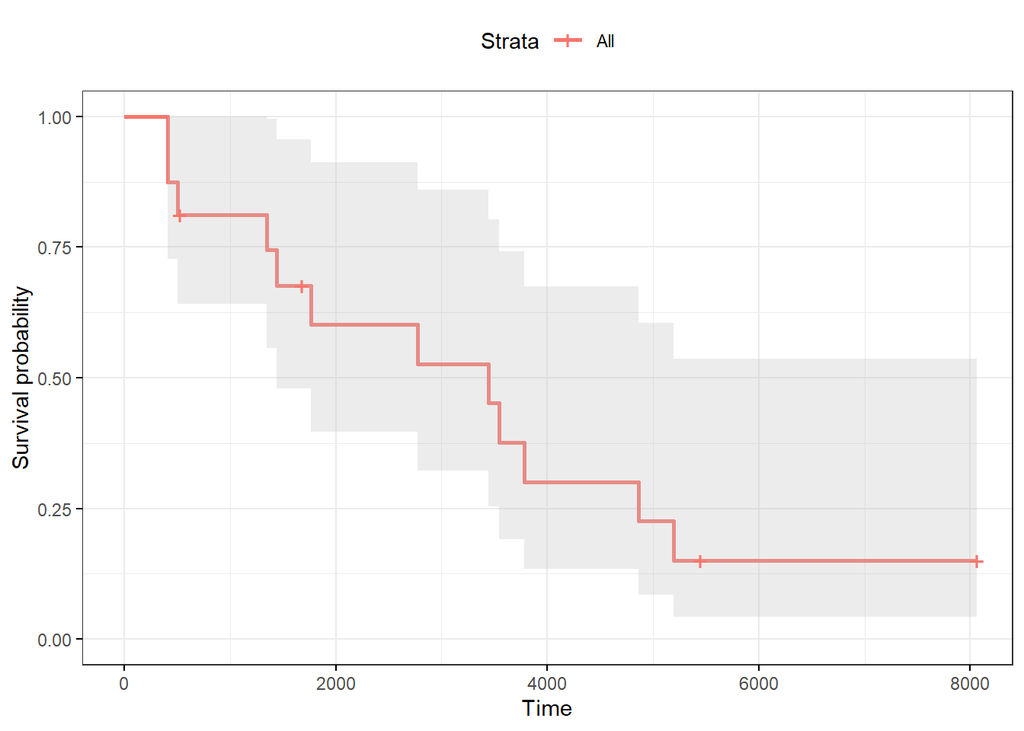

```r
ggsurvplot(fit,conf.int = TRUE,risk.table.col = "strata",ggtheme = theme_bw())
```

### (2) hours(censor==1 : event)에 대해 온도(temperature)에 따른 Kaplan-Meier 생존함수를 구하고 생존함수 그림을 그리시오.

#### 온도에 따른 Kaplan-Meier 생존함수를 구하면 다음과 같다.

```r
fit1 <- survfit(Surv(hours, censor==1) ~ temperature, data=electric)
summary(fit1)
```

```
## Call: survfit(formula = Surv(hours, censor == 1) ~ temperature, data = electric)
##
##                 temperature=150
##      time n.risk n.event survival std.err lower 95% CI upper 95% CI
##
##                 temperature=170
##  time n.risk n.event survival std.err lower 95% CI upper 95% CI
##  1764      8       1    0.875   0.117       0.6734        1.000
##  2772      7       1    0.750   0.153       0.5027        1.000
##  3444      6       1    0.625   0.171       0.3654        1.000
##  3542      5       1    0.500   0.177       0.2500        1.000
##  3780      4       1    0.375   0.171       0.1533        0.917
##  4860      3       1    0.250   0.153       0.0753        0.830
##  5196      2       1    0.125   0.117       0.0200        0.782
##
##                 temperature=190
##  time n.risk n.event survival std.err lower 95% CI upper 95% CI
##   408      4       1     0.75   0.217       0.4259            1
##  1344      3       1     0.50   0.250       0.1877            1
##  1440      2       1     0.25   0.217       0.0458            1
##
##                 temperature=220
##  time n.risk n.event survival std.err lower 95% CI upper 95% CI
##   408      3       1    0.667   0.272       0.2995            1
##   504      2       1    0.333   0.272       0.0673            1
```

#### 이에 대한 그림은 다음과 같이 그릴 수 있다.

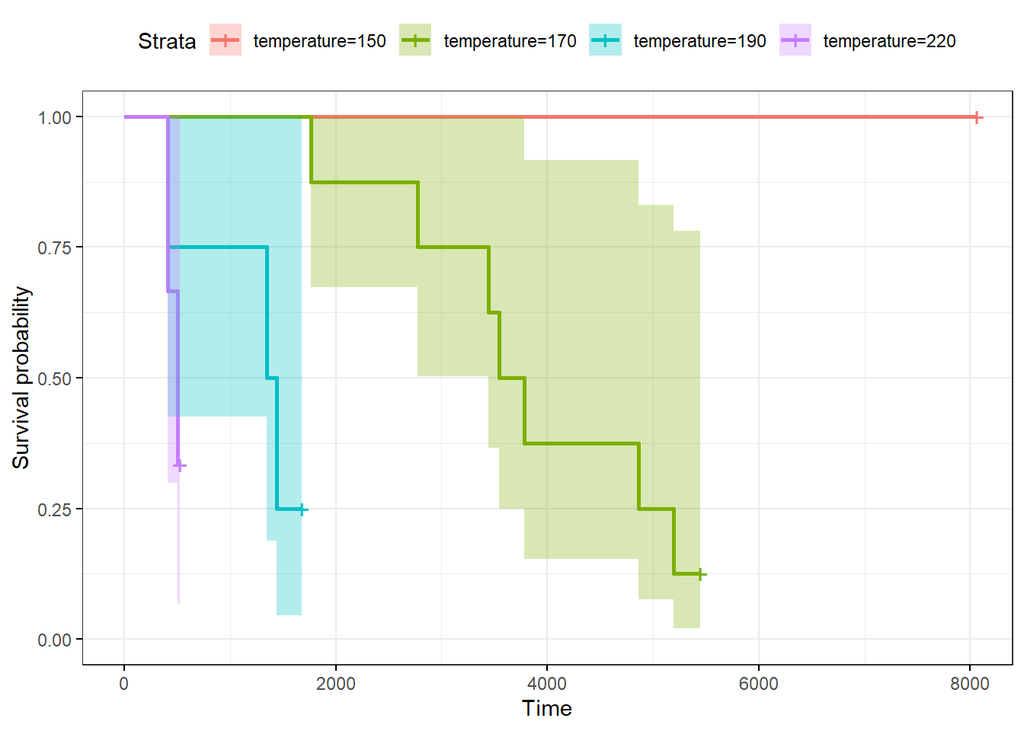

```r
ggsurvplot(fit1,conf.int = TRUE,risk.table.col = "strata",ggtheme = theme_bw())
```

#### 생존함수 그림에서 교차가 일어나지 않고 있으므로 이에 따른 log-rank test를 수행해보면 다음과 같다.

```r
survdiff(Surv(hours, censor==1) ~ temperature, data=electric, rho=0)
```

```
## Call:
## survdiff(formula = Surv(hours, censor == 1) ~ temperature, data = electric,
##     rho = 0)
##
##                 N Observed Expected (O-E)^2/E (O-E)^2/V
## temperature=150 1        0    1.700      1.70      2.10
## temperature=170 8        7    8.636      0.31      1.23
## temperature=190 4        3    1.146      3.00      4.02
## temperature=220 3        2    0.518      4.24      5.40
##
##  Chisq= 13.1  on 3 degrees of freedom, p= 0.005
```

#### p-value의 값이 0.005이므로 유의수준 0.05보다 작다. 이에 따라 온도에 따른 생존함수는 차이가 있다고 말할 수 있다.

### (3) hours(censor==1 : event)에 대해 공변량을 포함하지 않은 지수회귀모형을 적합하고 추정된 생존함수식을 쓰시오.

```r
a1 <- survreg(Surv(hours, censor==1) ~ 1, data=electric, dist="exponential")
summary(a1)
```

```
##
## Call:
## survreg(formula = Surv(hours, censor == 1) ~ 1, data = electric,
##     dist = "exponential")
##             Value Std. Error    z      p
## (Intercept) 8.234      0.289 28.5 <2e-16
##
## Scale fixed at 1
##
## Exponential distribution
## Loglik(model)= -110.8   Loglik(intercept only)= -110.8
## Number of Newton-Raphson Iterations: 4
## n= 16
```

#### 추정된 생존함수식은 다음과 같다.

- $logT=\beta_{0}+\epsilon$ 적합결과 ${\hat{\beta_{0}}}=8.234$ 이고 검정결과 $p-value<2 * 10 ^{-16}$ 이므로 매우 유의하다. 이에 따른 추정식은 $logT=8.234$ 이고 생존함수식은 다음과 같다.
- ${\hat{S}} (t)=exp[-t * exp(- {\hat{\beta _{0}}} )]=exp(-e ^{-8.234} t)$

### (4) hours(censor==1 : event)에 대해 공변량을 포함하지 않은 와이블회귀모형을 적합하고 추정된 생존함수식을 쓰시오.

```r
a2 <- survreg(Surv(hours, censor==1) ~ 1, data=electric, dist="weibull")
summary(a2)
```

```
##
## Call:
## survreg(formula = Surv(hours, censor == 1) ~ 1, data = electric,
##     dist = "weibull")
##              Value Std. Error     z      p
## (Intercept)  8.241      0.243 33.87 <2e-16
## Log(scale)  -0.174      0.234 -0.74   0.46
##
## Scale= 0.841
##
## Weibull distribution
## Loglik(model)= -110.5   Loglik(intercept only)= -110.5
## Number of Newton-Raphson Iterations: 6
## n= 16
```

#### 추정된 생존함수식은 다음과 같다.

- $logT= \beta _{0} + \sigma \epsilon$ 적합결과 ${\hat{\beta_{0}}}=8.241$ 이고 검정결과 $p-value<2 * 10 ^{-16}$ 이므로 매우 유의하다. 또한 이에 따른 추정식은 $logT=8.241$ 이고 생존함수식은 다음과 같다. ($\kappa=0.841$)
- ${\hat{S}}(t)=exp[-t ^{{\hat{\kappa }}} exp(- {\hat{\beta _{0}}} ) ^{{\hat{\kappa }}} ]=exp[-t ^{0.841} (exp(-8.241)) ^{0.841} ]$

### (5) hours(censor==1 : event)에 대해 공변량으로 온도를 포함한 지수회귀모형을 적합하고 추정된 생존함수식을 쓰시오.

```r
b1 <- survreg(Surv(hours, censor==1) ~ temperature, data=electric, dist="exponential")
summary(b1)
```

```
##
## Call:
## survreg(formula = Surv(hours, censor == 1) ~ temperature, data = electric,
##     dist = "exponential")
##               Value Std. Error     z       p
## (Intercept) 15.7563     2.5034  6.29 3.1e-10
## temperature -0.0428     0.0136 -3.15  0.0016
##
## Scale fixed at 1
##
## Exponential distribution
## Loglik(model)= -106.9   Loglik(intercept only)= -110.8
##  Chisq= 7.73 on 1 degrees of freedom, p= 0.0054
## Number of Newton-Raphson Iterations: 3
## n= 16
```

#### 분석결과

- 분석결과 변수 temperature에 대해 $\alpha=0.05$에서 회귀계수의 검정결과가 유의하다. 그리고 모형 전체에 대해서는 log-likelihood 검정결과 $p-value=0.0054$로 매우 유의함을 알 수 있다.
- ${\hat{S}} (t)=exp[- {\hat{\lambda }} t]=exp[-t*exp(- {\hat{\beta _{0}}} - {\hat{\beta _{1}}} Z _{1} )]$ $=exp[-t*exp(-15.7563+0.0428temperature)]$

### (6) hours(censor==1 : event)에 대해 공변량으로 온도를 포함한 와이블회귀모형을 적합하고 추정된 생존함수식을 쓰시오.

```r
b2 <- survreg(Surv(hours, censor==1) ~ temperature, data=electric, dist="weibull")
summary(b2)
```

```
##
## Call:
## survreg(formula = Surv(hours, censor == 1) ~ temperature, data = electric,
##     dist = "weibull")
##                Value Std. Error     z      p
## (Intercept) 15.72183    0.80054 19.64 <2e-16
## temperature -0.04321    0.00434 -9.96 <2e-16
## Log(scale)  -1.13246    0.24547 -4.61  4e-06
##
## Scale= 0.322
##
## Weibull distribution
## Loglik(model)= -100.2   Loglik(intercept only)= -110.5
##  Chisq= 20.76 on 1 degrees of freedom, p= 5.2e-06
## Number of Newton-Raphson Iterations: 6
## n= 16
```

#### 분석결과

- 분석결과 변수 temperature에 대해 $\alpha=0.05$에서 회귀계수의 검정결과가 유의하다. 그리고 모형 전체에 대해서는 log-likelihood 검정결과 $p-value=5.2 * 10 ^{-6}$로 매우 유의함을 알 수 있다.
- ${\hat{S}} (t)=exp[-( {\hat{\lambda }} t) ^{{\hat{\kappa }}} ]=$ $exp[-t ^{{\hat{\kappa }}} (exp(- {\hat{\beta _{0}}} - {\hat{\beta _{1}}} Z _{1} )) ^{{\hat{\kappa }}} ]$ $=exp[-t ^{0.322} (exp(-15.72183+0.04321temperature)) ^{0.322} ]$

### (7) 자연로그를 취한 반응값 log(hours) (censor==1 : event)에 대해 Kaplan-Meier 생존함수를 구하고 생존함수 그림을 그리시오.

```r
Surv(log(hours), censor==1)
```

```
##  [1] 8.995165+ 7.475339  7.927324  8.144389  8.172447  8.237479  8.488794
##  [8] 8.555644  8.603004+ 6.011267  7.203406  7.272398  7.426549+ 6.011267
## [15] 6.222576  6.269096+
```

#### Kaplan-Meier 생존함수를 구하면 다음과 같다.

```r
fit <- survfit(Surv(log(hours), censor==1) ~ 1, data=electric)
summary(fit)
```

```
## Call: survfit(formula = Surv(log(hours), censor == 1) ~ 1, data = electric)
##
##  time n.risk n.event survival std.err lower 95% CI upper 95% CI
##  6.01     16       2    0.875  0.0827       0.7271        1.000
##  6.22     14       1    0.812  0.0976       0.6421        1.000
##  7.20     12       1    0.745  0.1105       0.5569        0.996
##  7.27     11       1    0.677  0.1194       0.4792        0.957
##  7.48      9       1    0.602  0.1276       0.3972        0.912
##  7.93      8       1    0.527  0.1320       0.3222        0.861
##  8.14      7       1    0.451  0.1329       0.2535        0.804
##  8.17      6       1    0.376  0.1303       0.1908        0.742
##  8.24      5       1    0.301  0.1241       0.1341        0.675
##  8.49      4       1    0.226  0.1136       0.0842        0.605
##  8.56      3       1    0.150  0.0975       0.0422        0.536
```

#### 이에 대한 그림은 다음과 같이 그릴 수 있다.

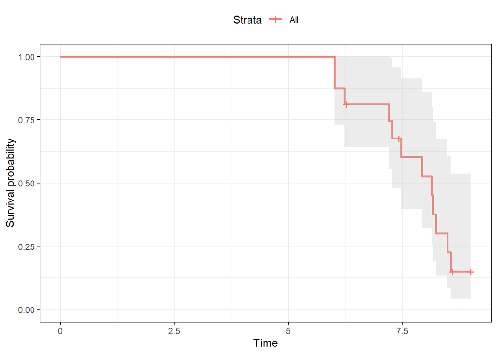

```r
ggsurvplot(fit,conf.int = TRUE,risk.table.col = "strata",ggtheme = theme_bw())
```

### (8) 자연로그를 취한 반응값 log(hours) (censor==1 : event)에 대해 온도에 따른 Kaplan-Meier 생존함수를 구하고 생존함수 그림을 그리시오.

#### 온도에 따른 Kaplan-Meier 생존함수를 구하면 다음과 같다.

```r
fit1 <- survfit(Surv(log(hours), censor==1) ~ temperature, data=electric)
summary(fit1)
```

```
## Call: survfit(formula = Surv(log(hours), censor == 1) ~ temperature,
##     data = electric)
##
##                 temperature=150
##      time n.risk n.event survival std.err lower 95% CI upper 95% CI
##
##                 temperature=170
##  time n.risk n.event survival std.err lower 95% CI upper 95% CI
##  7.48      8       1    0.875   0.117       0.6734        1.000
##  7.93      7       1    0.750   0.153       0.5027        1.000
##  8.14      6       1    0.625   0.171       0.3654        1.000
##  8.17      5       1    0.500   0.177       0.2500        1.000
##  8.24      4       1    0.375   0.171       0.1533        0.917
##  8.49      3       1    0.250   0.153       0.0753        0.830
##  8.56      2       1    0.125   0.117       0.0200        0.782
##
##                 temperature=190
##  time n.risk n.event survival std.err lower 95% CI upper 95% CI
##  6.01      4       1     0.75   0.217       0.4259            1
##  7.20      3       1     0.50   0.250       0.1877            1
##  7.27      2       1     0.25   0.217       0.0458            1
##
##                 temperature=220
##  time n.risk n.event survival std.err lower 95% CI upper 95% CI
##  6.01      3       1    0.667   0.272       0.2995            1
##  6.22      2       1    0.333   0.272       0.0673            1
```

#### 이에 대한 그림은 다음과 같이 그릴 수 있다.

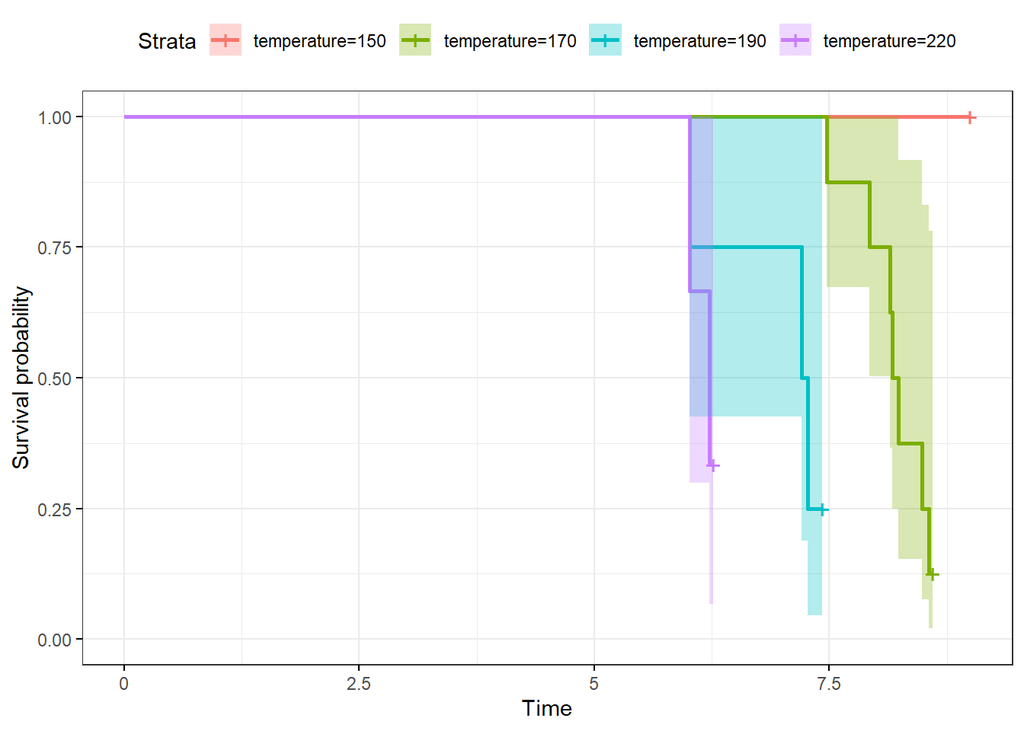

```r
ggsurvplot(fit1,conf.int = TRUE,risk.table.col = "strata",ggtheme = theme_bw())
```

#### 생존함수 그림에서 교차가 일어나지 않고 있으므로 이에 따른 log-rank test를 수행해보면 다음과 같다.

```r
survdiff(Surv(log(hours), censor==1) ~ temperature, data=electric, rho=0)
```

```
## Call:
## survdiff(formula = Surv(log(hours), censor == 1) ~ temperature,
##     data = electric, rho = 0)
##
##                 N Observed Expected (O-E)^2/E (O-E)^2/V
## temperature=150 1        0    1.700      1.70      2.10
## temperature=170 8        7    8.636      0.31      1.23
## temperature=190 4        3    1.146      3.00      4.02
## temperature=220 3        2    0.518      4.24      5.40
##
##  Chisq= 13.1  on 3 degrees of freedom, p= 0.005
```

#### p-value의 값이 0.005이므로 유의수준 0.05보다 작다. 이에 따라 온도에 따른 생존함수는 차이가 있다고 말할 수 있다.

### (9) 자연로그를 취한 반응값 log(hours) (censor==1 : event)에 대해 공변량을 포함하지 않은 지수회귀모형을 적합하고 추정된 생존함수식을 쓰시오.

```r
a1 <- survreg(Surv(log(hours), censor==1) ~ 1, data=electric, dist="exponential")
summary(a1)
```

```
##
## Call:
## survreg(formula = Surv(log(hours), censor == 1) ~ 1, data = electric,
##     dist = "exponential")
##             Value Std. Error    z       p
## (Intercept) 2.311      0.289 8.01 1.2e-15
##
## Scale fixed at 1
##
## Exponential distribution
## Loglik(model)= -39.7   Loglik(intercept only)= -39.7
## Number of Newton-Raphson Iterations: 3
## n= 16
```

#### 추정된 생존함수식은 다음과 같다.

- $logT=\beta_{0}+\epsilon$ 적합결과 ${\hat{\beta_{0}}}=2.311$ 이고 검정결과 $p-value<1.2 * 10 ^{-15}$ 이므로 매우 유의하다. 이에 따른 추정식은 $logT=2.311$ 이고 생존함수식은 다음과 같다. ($T=log(hours)$)
- ${\hat{S}} (t)=exp[-t * exp(- {\hat{\beta _{0}}} )]=exp(-e ^{-2.311} t)$

### (10) 자연로그를 취한 반응값 log(hours) (censor==1 : event)에 대해 공변량을 포함하지 않은 와이블회귀모형을 적합하고 추정된 생존함수식을 쓰시오.

```r
a2 <- survreg(Surv(log(hours), censor==1) ~ 1, data=electric, dist="weibull")
summary(a2)
```

```
##
## Call:
## survreg(formula = Surv(log(hours), censor == 1) ~ 1, data = electric,
##     dist = "weibull")
##               Value Std. Error     z      p
## (Intercept)  2.1056     0.0319 65.98 <2e-16
## Log(scale)  -2.2044     0.2383 -9.25 <2e-16
##
## Scale= 0.11
##
## Weibull distribution
## Loglik(model)= -20.6   Loglik(intercept only)= -20.6
## Number of Newton-Raphson Iterations: 6
## n= 16
```

#### 추정된 생존함수식은 다음과 같다.

- $logT= \beta _{0} + \sigma \epsilon$ 적합결과 ${\hat{\beta_{0}}}=2.1056$ 이고 검정결과 $p-value<2 * 10 ^{-16}$ 이므로 매우 유의하다. 또한 이에 따른 추정식은 $logT=2.1056$ 이고 생존함수식은 다음과 같다. ($\kappa=0.11$, $T=log(hours)$)
- ${\hat{S}}(t)=exp[-t ^{{\hat{\kappa }}} exp(- {\hat{\beta _{0}}} ) ^{{\hat{\kappa }}} ]=exp[-t ^{0.11} (exp(-2.1056)) ^{0.11} ]$

### (11) 자연로그를 취한 반응값 log(hours) (censor==1 : event)에 대해 공변량으로 온도를 포함한 지수회귀모형을 적합하고 추정된 생존함수식을 쓰시오.

```r
b1 <- survreg(Surv(log(hours), censor==1) ~ temperature, data=electric, dist="exponential")
summary(b1)
```

```
##
## Call:
## survreg(formula = Surv(log(hours), censor == 1) ~ temperature,
##     data = electric, dist = "exponential")
##                Value Std. Error     z    p
## (Intercept)  3.45244    2.57284  1.34 0.18
## temperature -0.00627    0.01395 -0.45 0.65
##
## Scale fixed at 1
##
## Exponential distribution
## Loglik(model)= -39.6   Loglik(intercept only)= -39.7
##  Chisq= 0.2 on 1 degrees of freedom, p= 0.66
## Number of Newton-Raphson Iterations: 3
## n= 16
```

#### 분석결과

- 분석결과 변수 temperature에 대해 $\alpha=0.05$에서 회귀계수의 검정결과가 유의하지 않다. 그리고 모형 전체에 대해서도 log-likelihood 검정결과 $p-value=0.66$으로 유의하지 않음을 알 수 있다. ($T=log(hours)$)
- ${\hat{S}} (t)=exp[- {\hat{\lambda }} t]=exp[-t*exp(- {\hat{\beta _{0}}} - {\hat{\beta _{1}}} Z _{1} )]$ $=exp[-t*exp(-3.45244+0.00627temperature)]$

### (12) 자연로그를 취한 반응값 log(hours) (censor==1 : event)에 대해 공변량으로 온도를 포함한 와이블회귀모형을 적합하고 추정된 생존함수식을 쓰시오.

```r
b2 <- survreg(Surv(log(hours), censor==1) ~ temperature, data=electric, dist="weibull")
summary(b2)
```

```
##
## Call:
## survreg(formula = Surv(log(hours), censor == 1) ~ temperature,
##     data = electric, dist = "weibull")
##                 Value Std. Error     z      p
## (Intercept)  3.127141   0.107119  29.2 <2e-16
## temperature -0.005897   0.000581 -10.2 <2e-16
## Log(scale)  -3.182171   0.248181 -12.8 <2e-16
##
## Scale= 0.0415
##
## Weibull distribution
## Loglik(model)= -10   Loglik(intercept only)= -20.6
##  Chisq= 21.26 on 1 degrees of freedom, p= 4e-06
## Number of Newton-Raphson Iterations: 6
## n= 16
```

#### 분석결과

- 분석결과 변수 temperature에 대해 $\alpha=0.05$에서 회귀계수의 검정결과가 유의하다. 그리고 모형 전체에 대해서는 log-likelihood 검정결과 $p-value=4 * 10 ^{-6}$로 매우 유의함을 알 수 있다. ($\kappa=0.0415$, $T=log(hours)$)
- ${\hat{S}} (t)=exp[-( {\hat{\lambda }} t) ^{{\hat{\kappa }}} ]=$ $exp[-t ^{{\hat{\kappa }}} (exp(- {\hat{\beta _{0}}} - {\hat{\beta _{1}}} Z _{1} )) ^{{\hat{\kappa }}} ]$ $=exp[-t ^{0.0415} (exp(-3.127141+0.005897temperature)) ^{0.0415} ]$